# ARMA vignette

**Generative AI Statement:** Used generative AI to help with parts of the website design, wording, and some code cleanup while building the Shiny app.

Before we start, we setup the variables needed for the demonstration.

```r
set.seed(42)
n <- 20
sigma <- 1.5
b <- c(0.2, 2) # b1, b0

# Data-generating process (DGP): ARMA(2,2)
p_arma22 <- c(0.60, -0.30)
q_arma22 <- c(0.45, -0.20)
```

This vignette uses one ARMA(2,2)-generated dataset. It demonstrates the diagnostic tools available in the app: stationary checking, model fitting, residual analysis, ACF/PACF plots, and coefficient inspection. It compares five fitted models:

1. LR baseline (`p = 0, q = 0`)
2. ARMA(1,1) (`p = 1, q = 1`)
3. MA(2) (`p = 0, q = 2`)
4. AR(2) (`p = 2, q = 0`)
5. ARMA(2,2) (`p = 2, q = 2`)

## Stationarity and Characteristic Roots

We say an AR process is “stationary” when all roots of its characteristic polynomial lie **outside** the unit circle. Equivalently, their modulus must be greater than 1.

```r
check_stationarity <- function(ar_coefs) {
  if (length(ar_coefs) == 0)
    return(list(stationary = TRUE, roots = numeric(0)))
  roots <- Mod(polyroot(c(1, -ar_coefs)))
  list(stationary = all(roots > 1), roots = roots)
}

result <- check_stationarity(p_arma22)
cat("Stationary:", result$stationary, "\n")
```

```
#> Stationary: TRUE
```

```r
cat("Characteristic root moduli:", round(result$roots, 4), "\n")
```

```
#> Characteristic root moduli: 1.8257 1.8257
```

As you can see, both roots exceed 1. Therefore, we can say that ARMA(2,2) is stationary. In the app, a green badge confirms stationary and displalys the root values live as you change the AR coefficients. If a red badge appears, then you have entered coefficients that push a root inside the unit circle.

## Generate ARMA(2,2) Errors and Dataset

```r
e_arma22 <- generate_ARMA_errors(
  n = n,
  p = p_arma22,
  q = q_arma22,
  sigma = sigma
)

d_arma22 <- generate_ARMA_dataset(
  n = n,
  p = p_arma22,
  q = q_arma22,
  sigma = sigma,
  b = b
)
```

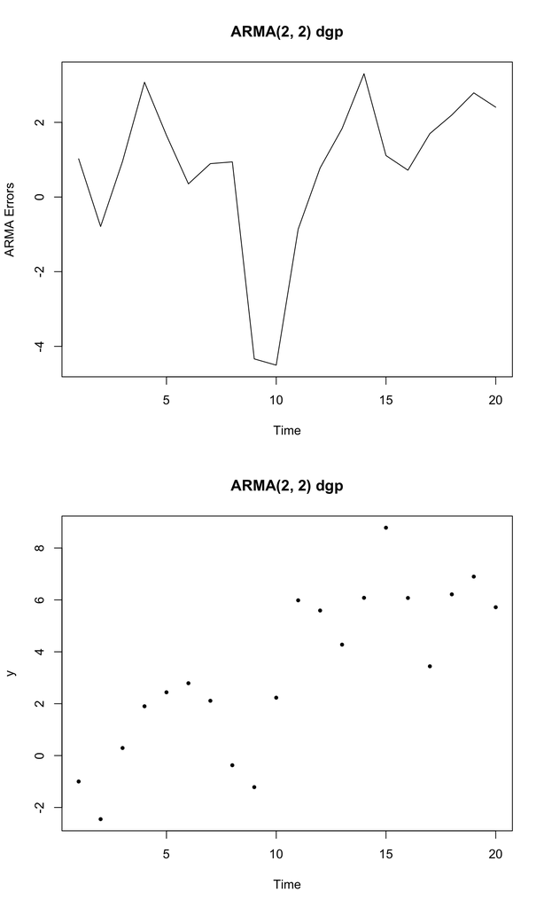

```r
par(mfrow = c(2, 1))
plot_ARMA_series(e_arma22, series = "e")
plot_ARMA_series(d_arma22, series = "y")
```

## Fit LR, ARMA(1,1), MA(2), AR(2), and ARMA(2,2)

```r
data_arma <- d_arma22

fit_lr <- fit_ARMA(data_arma, p_order = 0, q_order = 0)

fit_arma11 <- fit_ARMA(data_arma, p_order = 1, q_order = 1)

fit_ma2 <- fit_ARMA(data_arma, p_order = 0, q_order = 2)

fit_ar2 <- fit_ARMA(data_arma, p_order = 2, q_order = 0)

fit_arma22 <- fit_ARMA(data_arma, p_order = 2, q_order = 2)

# Compare innovation variances
fit_lr$sigma2
```

```
#> [1] 3.319284
```

```r
fit_arma11$sigma2
```

```
#> [1] 1.498589
```

```r
fit_ma2$sigma2
```

```
#> [1] 1.132383
```

```r
fit_ar2$sigma2
```

```
#> [1] 1.888665
```

```r
fit_arma22$sigma2
```

```
#> [1] 0.9722165
```

## Estimated Coefficients

The app’s **Estimated Coefficients** panel displays $\hat{\varphi}_i$, $\hat{\theta}_i$, $\hat{b}_0$, $\hat{b}_1$, and $\hat{\sigma}$ for the currently fitted model. Here we inspect them manually for each model.

```r
extract_coefs <- function(fit, label) {
  coefs <- coef(fit)
  sd_est <- sqrt(fit$sigma2)
  cat("---", label, "---\n")
  print(round(coefs, 4))
  cat("sigma:", round(sd_est, 4), "\n\n")
}

extract_coefs(fit_lr,     "LR baseline  (p=0, q=0)")
```

```
#> --- LR baseline  (p=0, q=0) ---
#> intercept    data$t
#>   -1.1675    0.4245
#> sigma: 1.8219
```

```r
extract_coefs(fit_arma11, "ARMA(1,1)    (p=1, q=1)")
```

```
#> --- ARMA(1,1)    (p=1, q=1) ---
#>       ar1       ma1 intercept    data$t
#>    0.1007    1.0000   -0.7182    0.3840
#> sigma: 1.2242
```

```r
extract_coefs(fit_ma2,    "MA(2)        (p=0, q=2)")
```

```
#> --- MA(2)        (p=0, q=2) ---
#>       ma1       ma2 intercept    data$t
#>    1.8599    1.0000   -0.3654    0.3704
#> sigma: 1.0641
```

```r
extract_coefs(fit_ar2,    "AR(2)        (p=2, q=0)")
```

```
#> --- AR(2)        (p=2, q=0) ---
#>       ar1       ar2 intercept    data$t
#>    0.6028   -0.5584   -0.8780    0.4027
#> sigma: 1.3743
```

```r
extract_coefs(fit_arma22, "ARMA(2,2)    (p=2, q=2)")
```

```
#> --- ARMA(2,2)    (p=2, q=2) ---
#>       ar1       ar2       ma1       ma2 intercept    data$t
#>    0.7880   -0.4312   -0.0668   -0.9332   -1.0388    0.4253
#> sigma: 0.986
```

## Residual Analysis

Good model fit means residuals should resemble white noise. No visible structure over time and no significant autocorrelation.

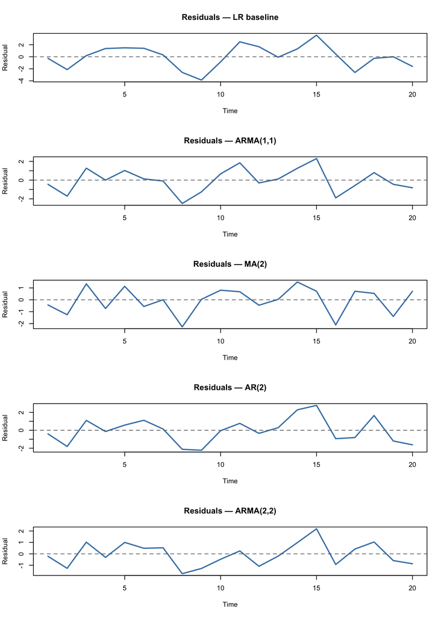

```r
par(mfrow = c(5, 1))

plot_residuals <- function(fit, label) {
  res  <- residuals(fit)
  keep <- is.finite(res)
  plot(which(keep), res[keep], type = "l", col = "steelblue", lwd = 2,
       xlab = "Time", ylab = "Residual", main = paste("Residuals —", label))
  abline(h = 0, lty = 2, col = "gray40")
}

plot_residuals(fit_lr,     "LR baseline")
plot_residuals(fit_arma11, "ARMA(1,1)")
plot_residuals(fit_ma2,    "MA(2)")
plot_residuals(fit_ar2,    "AR(2)")
plot_residuals(fit_arma22, "ARMA(2,2)")
```

The LR baseline shows clear serial structure. The ARMA(2,2) residuals look much closer to white noise. In the app the **Residuals** tab updates live whenever you change either the generating process or the fitted model order.

## ACF and PACF of Residuals

The ACF and PACF are the primary tools for diagnosing whether serial correlation remains in the residuals after fitting.

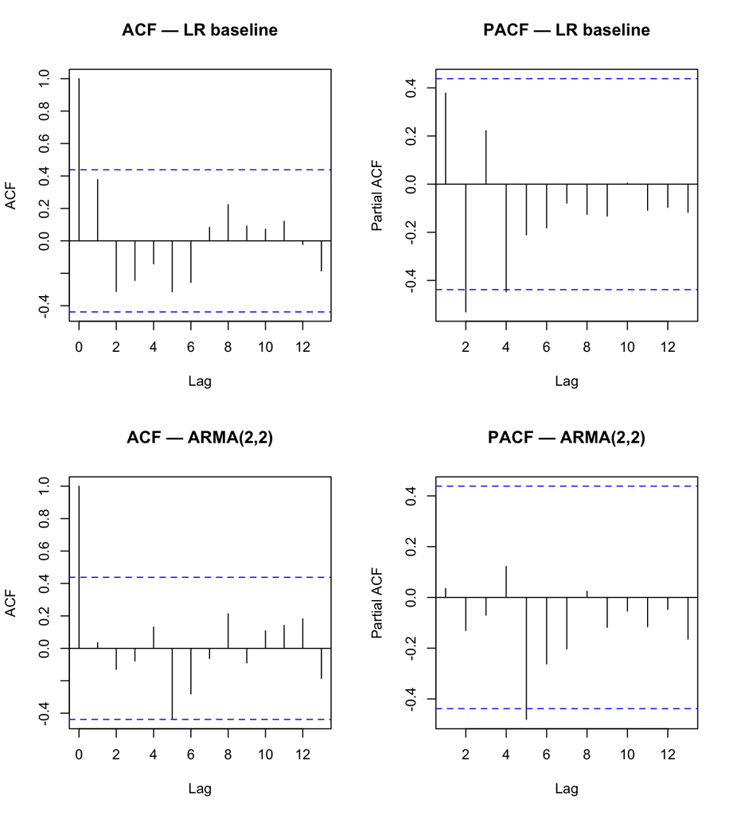

```r
par(mfrow = c(2, 2))

plot_acf_pacf <- function(fit, label) {
  res  <- residuals(fit)
  keep <- is.finite(res)
  acf( res[keep], main = paste("ACF —",  label))
  pacf(res[keep], main = paste("PACF —", label))
}

plot_acf_pacf(fit_lr,     "LR baseline")
plot_acf_pacf(fit_arma22, "ARMA(2,2)")
```

## Compare Fitted Curves and Error Fits

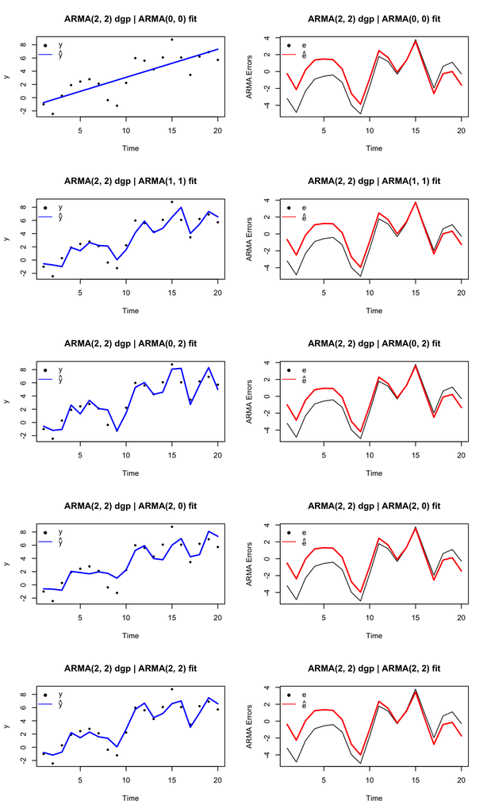

```r
par(mfrow = c(5, 2))

plot_ARMA_series(data_arma, series = "y", fit = fit_lr)
plot_ARMA_series(data_arma, series = "e", fit = fit_lr)

plot_ARMA_series(data_arma, series = "y", fit = fit_arma11)
plot_ARMA_series(data_arma, series = "e", fit = fit_arma11)

plot_ARMA_series(data_arma, series = "y", fit = fit_ma2)
plot_ARMA_series(data_arma, series = "e", fit = fit_ma2)

plot_ARMA_series(data_arma, series = "y", fit = fit_ar2)
plot_ARMA_series(data_arma, series = "e", fit = fit_ar2)

plot_ARMA_series(data_arma, series = "y", fit = fit_arma22)
plot_ARMA_series(data_arma, series = "e", fit = fit_arma22)
```

From these fit comparisons, the baseline LR model leaves clear serial structure in residuals. ARMA(1,1), MA(2), and AR(2) improve fit to different degrees, while ARMA(2,2) typically captures the DGP most closely.

## Bibliography

Chang W, Allaire J, Cheng J. 2025. “Shiny: Web Application Framework for r.” https://doi.org/10.32614/CRAN.package.shiny.

Douglas, Alex et al. n.d. “An Introduction to r.” https://intro2r.com/.

Nosedal, A. Sanchez. n.d. “Sta302-Classical-SLR-Assumptions.” Lecture. University of Toronto Mississauga.

———. n.d. “Sta302-Estimation-and-GM-Thm.” Lecture. University of Toronto Mississauga.

———. n.d. “Sta302-Slr-in-Matrix-Terms.” Lecture. University of Toronto Mississauga.

Nosedal, Al. 2025. “The Autocorrelation Function and AR(1), AR(2) Models.” University of Toronto Mississauga.

Rizzo, Maria L. 2007. *Statistical Computing with r*. CRC Press.

Wickham, Hadley. 2019. *Advanced r*. 2nd ed. Chapman; Hall/CRC. https://adv-r.hadley.nz/.